# NAPED — Portfólio de Ações | Junho 2026

Afya São João del Rei

Portfólio de Ações  
NAPED

Junho de 2026

Registro das iniciativas desenvolvidas pelo Núcleo de Apoio Pedagógico e Experiência Docente.

Ação 1Junho 2026

Visita do Gerente Pedagógico Nacional — Denny Almeida

Escuta, Alinhamentos e Planejamento

Recebemos a visita do Gerente Pedagógico Nacional Denny Almeida — uma visita cheia de escuta, alinhamentos e planejamento. Junto ao NAPED, às coordenações e às equipes que fazem a nossa IES acontecer todos os dias, foram realizados encontros com ENAMED, coordenação de Medicina, especialistas de eixo, coordenadores SHE e discussões sobre a Semana de Desenvolvimento Docente.

Escuta ativa, alinhamento pedagógico, planejamento institucional, integração entre setores.

Evidências

Card da Visita

[figure not shown]

Visita Denny Almeida — NAPED

Encontros com ENAMED, Coordenação de Medicina, Especialistas de Eixo, Coordenadores SHE e SDD

Alinhamento com Especialistas de Eixo e NAPED

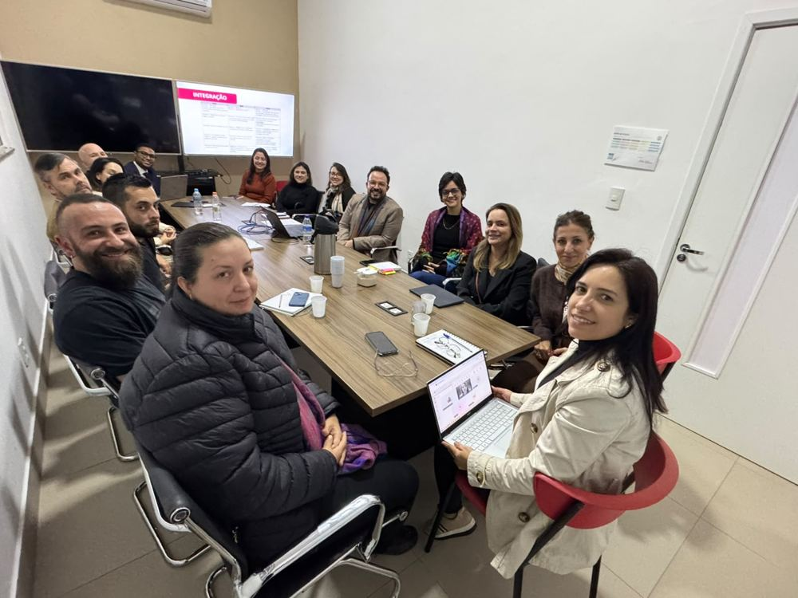

Denny, Especialistas de Eixo e NAPED

Reunião de alinhamento pedagógico

[figure not shown]

Denny, Especialistas e NAPED

Alinhamento com especialistas de eixo e equipe NAPED

Ação 2Junho 2026

Projeto Mentoria ENAMED

Formação de Mentores e Acompanhamento dos Estudantes

O Projeto Mentoria ENAMED estruturou um programa de acompanhamento individualizado dos estudantes de Medicina, com encontros quinzenais de uma hora em grupos reduzidos de até 10 alunos. A metodologia, orientada pelo NAPED/NED, foi apresentada por Denny Almeida e capacitou mentores docentes para atuar com escuta ativa, acolhimento e acompanhamento das trajetórias acadêmicas e emocionais dos estudantes em preparação para o ENAMED.

Mentoria, ENAMED, grupos reduzidos, escuta ativa, acompanhamento docente, NAPED/NED.

Evidências

Treinamento dos Mentores

[figure not shown]

A Metodologia de Sucesso

Cadência: encontros quinzenais; O Mentor: escuta e acolhimento; Governança: orientado pelo NAPED/NED

Bloco 1 — Trajetória, Pertencimento e Sentido

Encontros 1 e 2: minha trajetória na Medicina e o significado do ENAMED

[figure not shown]

Dinâmica dos Encontros: Estratégias e Princípios

Escuta inicial, identificação, definição de metas, acompanhamento e devolutiva

Encontros de Mentoria

[figure not shown]

Encontro com Mentores

Reunião online de acompanhamento do projeto

[figure not shown]

Encontro com Mentores

Reunião online de acompanhamento do projeto

[figure not shown]

Reunião de Alinhamento

Alinhamento entre mentores e equipe NAPED

[figure not shown]

Relatório de Presença

Evidência de presença — Reunião com Hellen Sueli Bergo, 27/05/2026, 9 participantes

Grupo de Mentores — Mentores Medicina 2026

[figure not shown]

Grupo Mentores Medicina 2026

Orientações e materiais compartilhados com os mentores

[figure not shown]

[figure not shown]

Grupo Mentores Medicina 2026

14 membros — compartilhamento de materiais e orientações pedagógicas

Ação 3Junho 2026

ENAMED em Foco

Encontros Diários e Alinhamento com Professores

O projeto ENAMED em Foco promoveu encontros diários às 19h para discussão de questões de ENAMED, Simulado e Revalida. No mês de maio, as temáticas abordadas foram Saúde Coletiva, Cirurgia, GO, Saúde Mental e Pediatria. Paralelamente, em 14/05, foi realizado alinhamento de orientações para organização das aulas teóricas do Internato, reunindo professores e coordenação de forma online.

Encontros diários 19h, ENAMED, Simulado, Revalida, aulas teóricas do Internato.

Evidências

[figure not shown]

Encontros Diários — ENAMED em Foco

Maio 2026: Saúde Coletiva, Cirurgia, GO, Saúde Mental e Pediatria — discussão de questões e simulados

[figure not shown]

Alinhamento — Aulas Teóricas do Internato

14/05: alinhamento de orientações para organização das aulas teóricas do Internato

[figure not shown]

Navegar pelo portfólio